# A Study of War

Adam Austin

## Playing the game

To simulate a game, we choose the number of ranks and suits in our deck (the default is 13 ranks and 4 suits, as in a standard 52-card deck).

The output is the number of rounds played in that game (*i.e.* the number of times cards are collected by one player) and the overall winner of that game.

```r
simulate_game(ranks = 13, suits = 4)
```

```
##    round_count winner
## p2         101      2
```

The game can easily take an hour or more when playing in real life. In this simulation, it takes milliseconds.

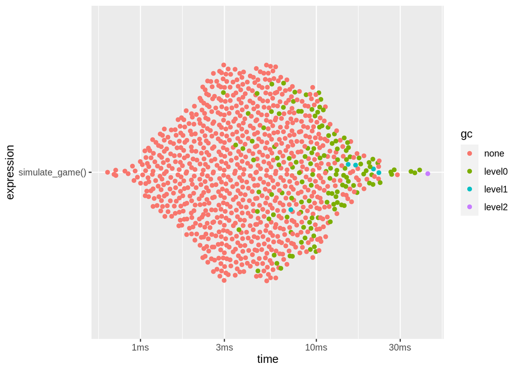

```r
benchmark <- mark(simulate_game(), iterations = 1000)
plot(benchmark)
```

## Statistics of multiple games

We simulate many games and examine the distribution of winners and rounds per game.

```r
games <- mclapply(1:10000, function(x) simulate_game(), mc.cores = detectCores() - 1)
games_data <- do.call(rbind, games)
head(games_data)
```

```
##     round_count winner
## p2          343      2
## p1          103      1
## p11          88      1
## p21          82      2
## p12          74      1
## p22         182      2
```

### How many rounds does it take to end the game?

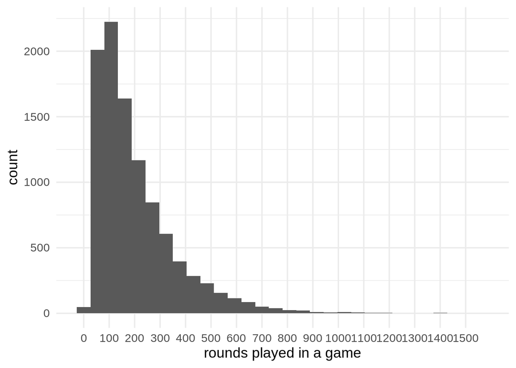

Some games are over in very few rounds. What do players’ starting hands looks like, after distributing the cards, when the game only lasts 10 rounds?

A deck is represented as a sampled (“shuffled”) vector of integers standing for the card ranks (2 through Ace are stored as 1 through 13), with repeating ranks for the suits (e.g. there are 4 copies of rank 10).

```
## This game ended in 10 rounds with player 1 winning.
```

```
##    player_1 player_2
## 1        13        1
## 2        12        3
## 3         8        6
## 4        10       10
## 5         5        6
## 6         1        4
## 7         8       13
## 8         9        2
## 9         7        7
## 10        2       13
## 11        5        4
## 12        2       12
## 13       12        3
## 14        7        7
## 15       10        1
## 16        4       11
## 17       12        3
## 18        8        8
## 19        9        5
## 20        3        4
## 21       11        6
## 22       11       10
## 23       13        1
## 24        9        5
## 25        6        2
## 26       11        9
```

### What proportion of games does each player win?

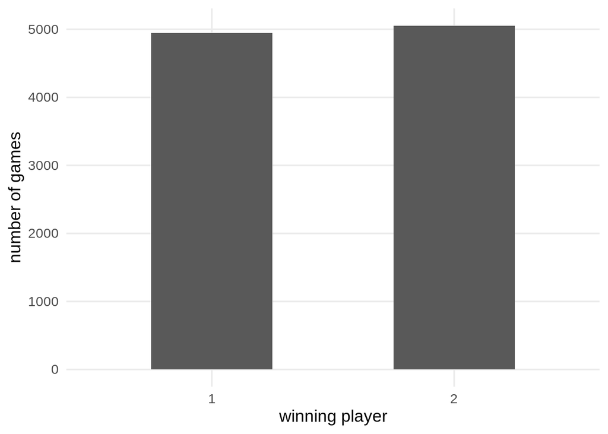

## How does the type of deck influence the game’s length?

A standard deck has 13 ranks with 4 suits each. As a useless thought exercise, what if we vary this? How does it affect the median game length (in number of rounds)? Here we simulate 200 games with each combination of ranks and suits.

(Note: the total number of cards must be even.)

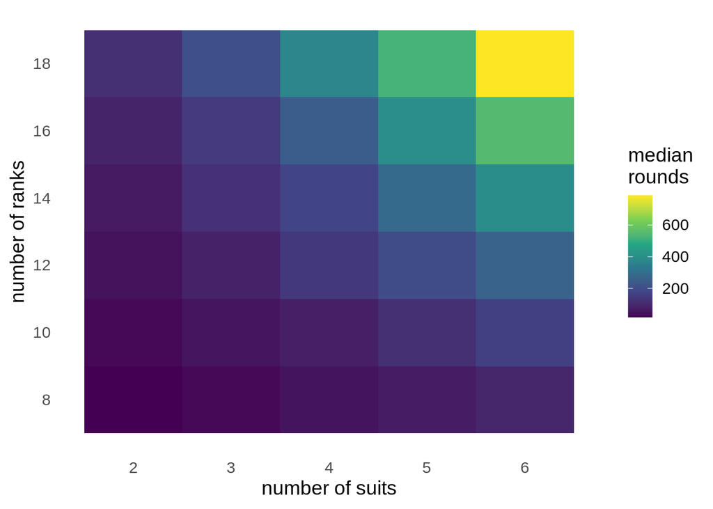

What if we normalize the round count by the number of cards in the deck?

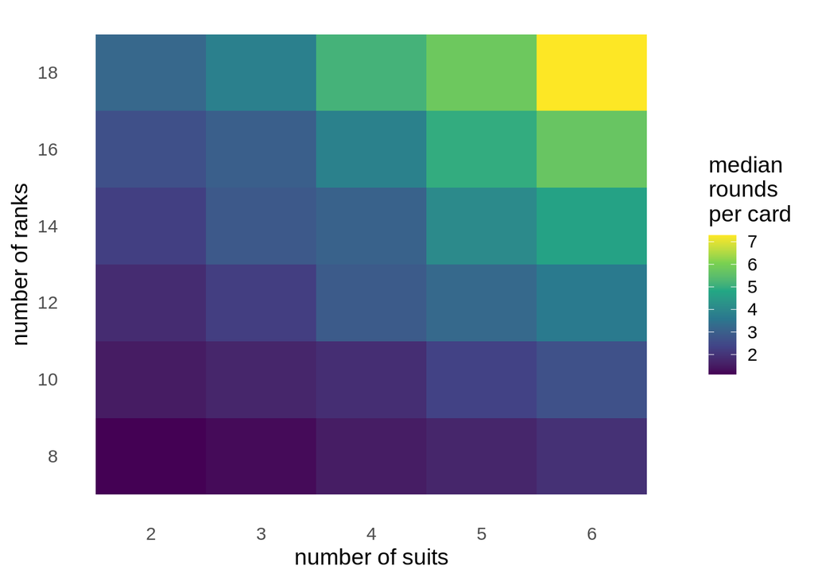